# Vignette 2: GSPCR specification options

Here we focus on the specifications of the GSPCR model. Three arguments of the `cv_gspcr()` should be specified carefully:

- Association measure
- Fit measure
- Number of components

In this vignette we consider a simple scenario with a continuous dependent variable and a set of continuous predictors. First, we load the required packages and store the **example dataset** `GSPCRexdata` (see the helpfile for details `?GSPCRexdata`) in two separate objects:

```r
# Load R packages
library(gspcr) # this package!
library(superpc) # alternative comparison package
library(patchwork) # combining ggplots

# Comment goal of code
X <- GSPCRexdata$X$cont
y <- GSPCRexdata$y$cont
```

# 1 Association measures

As described in the introduction, `gspcr` allows for the specification of **different bivariate association measures**. We can run `gspcr` using as a threshold type:

- the log-likelihoods of simple GLMs;
- the generalized $R^2$;
- the normalized association measure used in the `superpc` R package.

Another important aspect to consider is the **number of threshold values** that should be considered. This can be specified with the `nthrs` argument. Using the following code we can compare the solution paths obtained by the different association measures and values for a given number of PCs.

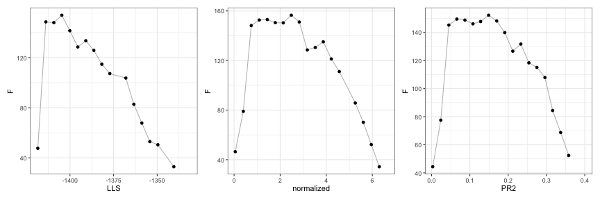

Figure 1: Solution paths for different association measures.

```r
# Define a vector of threshold types
threshold_types <- c("LLS", "normalized", "PR2")

# Train the GSPCR model with the different values
out_trhs <- lapply(
    X = threshold_types,
    FUN = function(i) {
        cv_gspcr(
            dv = y,
            ivs = X,
            thrs = i,       # threshold type
            nthrs = 20,     # number of threshold values
            npcs_range = 1,
            K = 10
        )
    }
)

# Plot them
plots <- lapply(out_trhs, function(i) {
    plot(
        x = i,
        y = "F",
        labels = FALSE,     # We are using a single nPC, do not need the label
        discretize = FALSE, # Makes X-axis more readable
        print = FALSE
    )
})

# Patchwork ggplots
plots[[1]] + plots[[2]] + plots[[3]]
```

As you can see, the solution paths are similar, although LLS tended to favor lower threshold values.

# 2 Fit measures

We can use **different cross-validation fit measures**. See the help file for the list options (`?cv_gspcr`).

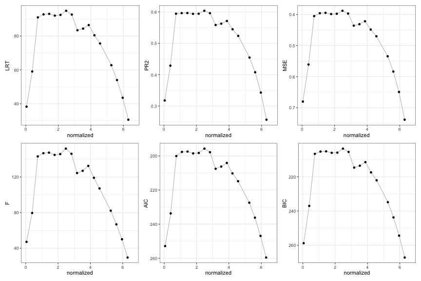

Figure 2: Solution paths for different fit measures.

```r
# Measures
fit_measure_vec <- c("LRT", "PR2", "MSE", "F", "AIC", "BIC")

# Train the GSPCR model with the different values
out_fit_meas <- lapply(fit_measure_vec, function(i) {
    cv_gspcr(
        dv = y,
        ivs = X,
        fit_measure = i,
        thrs = "normalized",
        nthrs = 20,
        npcs_range = 1,
        K = 10
    )
})

# Plot them
plots <- lapply(seq_along(fit_measure_vec), function(i) {
    # Reverse y?
    rev <- grepl("MSE|AIC|BIC", fit_measure_vec[i])

    # Make plots
    plot(
        x = out_fit_meas[[i]],
        y = fit_measure_vec[[i]],
        labels = FALSE,
        y_reverse = rev,
        errorBars = FALSE,
        discretize = FALSE,
        print = FALSE
    )
})

# Patchwork ggplots
(plots[[1]] + plots[[2]] + plots[[3]]) / (plots[[4]] + plots[[5]] + plots[[6]])
```

As you can see, the different fit measures return equivalent solution paths. This is true for **any number of PCs**:

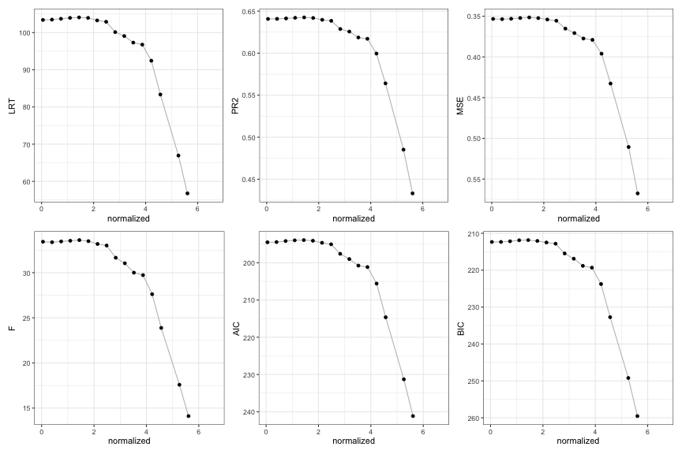

Figure 3: Solution paths for different fit measures when using 5 PCs.

```r
# Train the GSPCR model with the different values
out_fit_meas <- lapply(fit_measure_vec, function(i) {
    cv_gspcr(
        dv = y,
        ivs = X,
        fit_measure = i,
        thrs = "normalized",
        nthrs = 20,
        npcs_range = 5,
        K = 10
    )
})

# Plot them
plots <- lapply(seq_along(fit_measure_vec), function(i) {
    # Reverse y?
    rev <- grepl("MSE|AIC|BIC", fit_measure_vec[i])

    # Make plots
    plot(
        x = out_fit_meas[[i]],
        y = fit_measure_vec[[i]],
        labels = FALSE,
        y_reverse = rev,
        errorBars = FALSE,
        discretize = FALSE,
        print = FALSE
    )
})

# Patchwork ggplots
(plots[[1]] + plots[[2]] + plots[[3]]) / (plots[[4]] + plots[[5]] + plots[[6]])
```

# 3 Number of components

We can use cross-validation to **select the number of PCs** as well. We can use the `npcs_range` argument to specify the range of the number of PCs to consider.

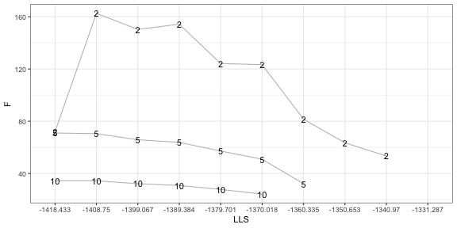

Figure 4: Solution paths for different fit measures when cross-validating the number of PCs.

```r
# Train the model
out_npcs <- cv_gspcr(
    dv = y,
    ivs = X,
    npcs_range = c(2, 5, 10)
)

# Plot solution paths
plot(out_npcs)
```

Given the choice of 2, 5, or 10 PCs, we would use 2 PCs with the second threshold value.